# Preparation

Marta Espinosa

2024-10-22

## TestisORFs

`/home/marta/PROJECT_SCRIPTS/TestisRestricted_MP/TSTR_Pipeline/1_TestisORFs_in1.Rmd`

```
## [1] "ORFs"
```

```
##
##               lncRNA                novel processed_pseudogene
##                 2317                  309                 1308
##       protein_coding
##                23172
```

```
## [1] "alt ORFs"
```

```
##
##               lncRNA_noncoding                novel_noncoding
##                           2317                            309
## processed_pseudogene_noncoding       protein_coding_canonical
##                           1308                          15454
##            protein_coding_dORF           protein_coding_odORF
##                           2185                            304
##           protein_coding_ouORF            protein_coding_uORF
##                           1191                           4038
```

```
## [1] "Genes"
```

```
##
##               lncRNA                novel processed_pseudogene
##                 1705                  192                  950
##       protein_coding
##                15782
```

```
##
##                        lncRNA_noncoding novel_noncoding
##   lncRNA                           1705               0
##   novel                               0             192
##   processed_pseudogene                0               0
##   protein_coding                      0               0
##
##                        processed_pseudogene_noncoding protein_coding_canonical
##   lncRNA                                            0                        0
##   novel                                             0                        0
##   processed_pseudogene                            950                        0
##   protein_coding                                    0                    15454
##
##                        protein_coding_dORF protein_coding_odORF
##   lncRNA                                 0                    0
##   novel                                  0                    0
##   processed_pseudogene                   0                    0
##   protein_coding                      1520                  304
##
##                        protein_coding_ouORF protein_coding_uORF
##   lncRNA                                  0                   0
##   novel                                   0                   0
##   processed_pseudogene                    0                   0
##   protein_coding                       1181                3156
```

```
## [1] 204
```

```
## [1] 158
```

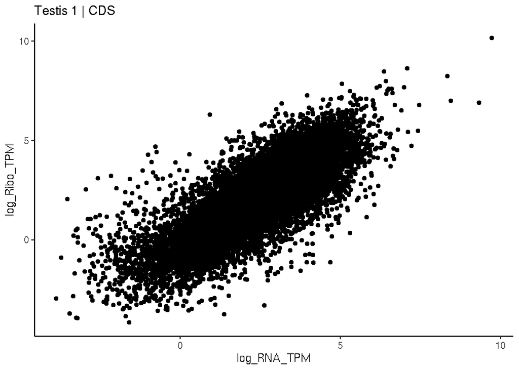

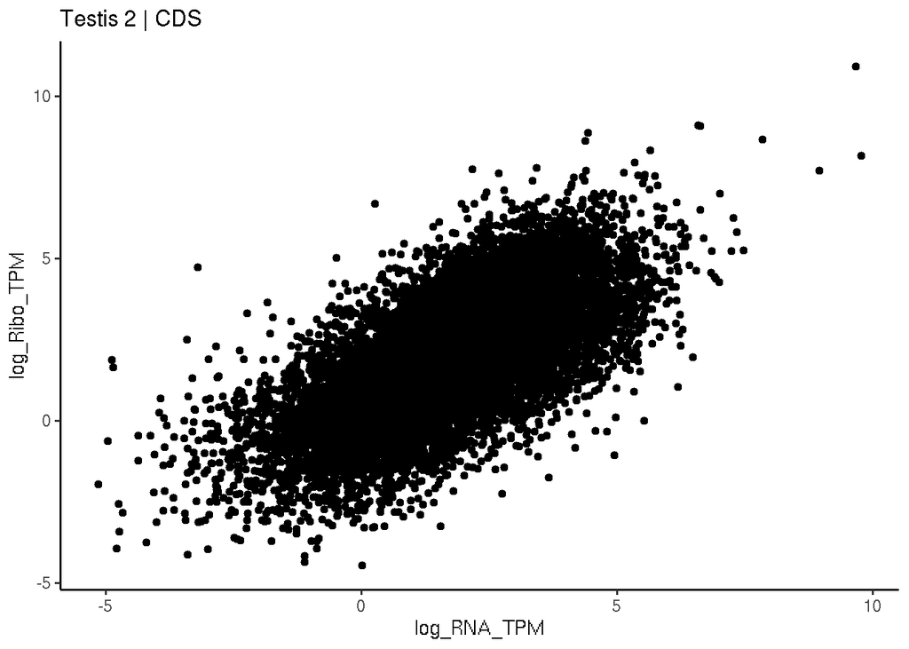

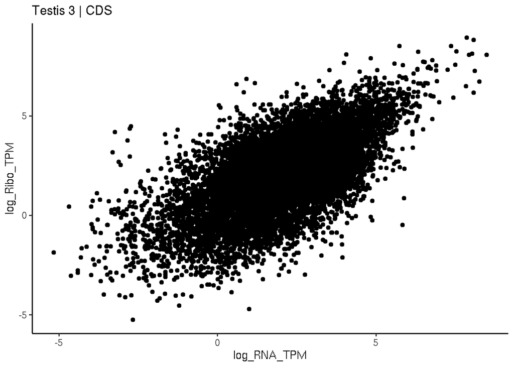

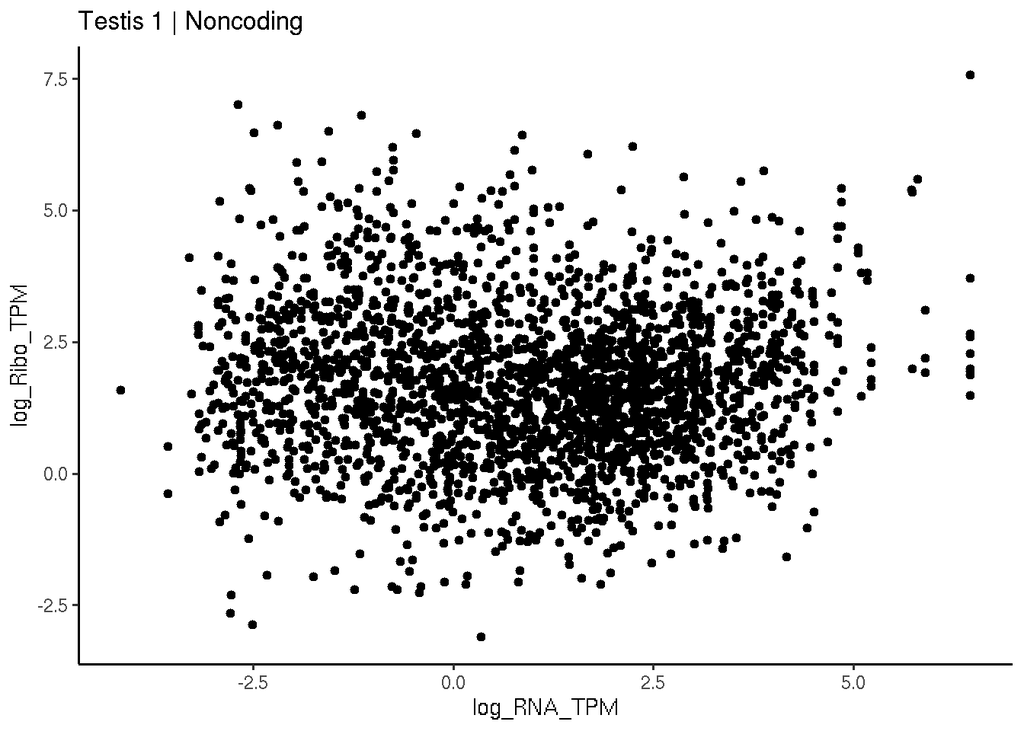

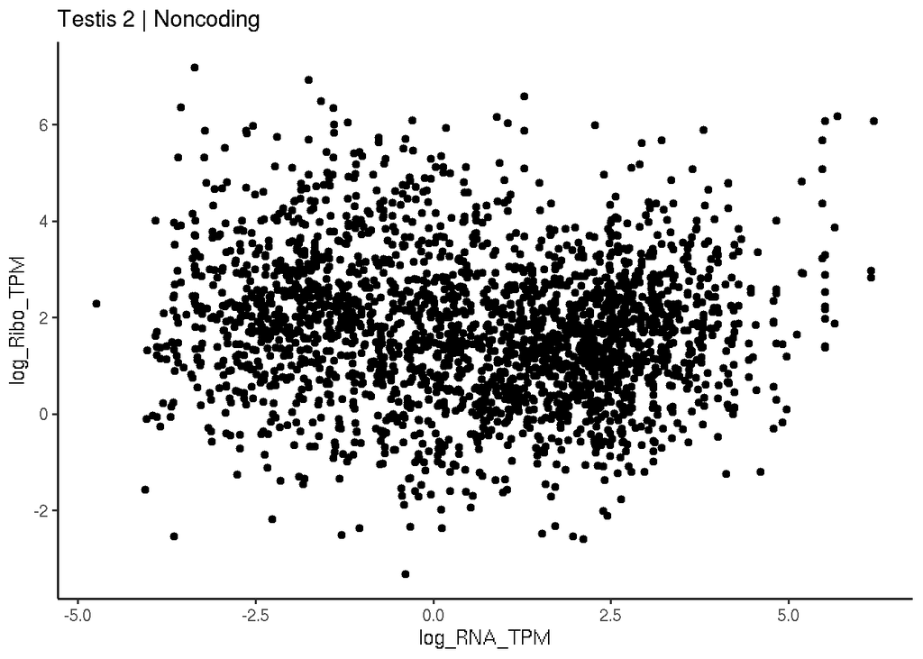

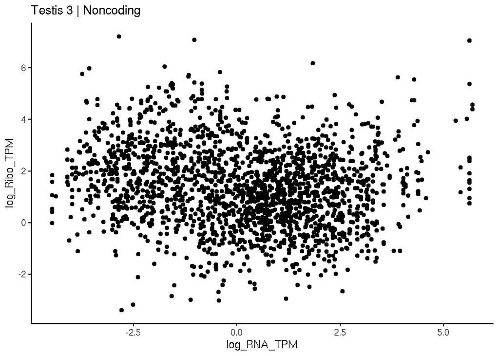

[figure not shown]

[figure not shown]

[figure not shown]

## TestisRestricted - No Present in Proteome (BLASTP)

`/home/marta/PROJECT_SCRIPTS/TestisRestricted_MP/TSTR_Pipeline/2_TestisRestricted_in1.Rmd` `/home/marta/PROJECT_SCRIPTS/TestisRestricted_MP/TSTR_Pipeline/3_TestisRestricted_BLASTP_ncORFSvsCDS.ipynb`

```
## [1] "ORFs"
```

```
##
##               lncRNA                novel processed_pseudogene
##                  331                  224                   31
##       protein_coding
##                  497
```

```
## [1] "alt ORFs"
```

```
##
##               lncRNA_noncoding                novel_noncoding
##                            331                            224
## processed_pseudogene_noncoding       protein_coding_canonical
##                             31                            356
##            protein_coding_dORF           protein_coding_odORF
##                             31                             11
##           protein_coding_ouORF            protein_coding_uORF
##                             34                             65
```

```
## [1] "Genes"
```

```
##
##               lncRNA                novel processed_pseudogene
##                  257                  116                   24
##       protein_coding
##                  374
```

```
## [1] "ORFs"
```

```
##
##               lncRNA                novel processed_pseudogene
##                  326                  222                   11
##       protein_coding
##                  484
```

```
## [1] "alt ORFs"
```

```
##
##               lncRNA_noncoding                novel_noncoding
##                            326                            222
## processed_pseudogene_noncoding       protein_coding_canonical
##                             11                            356
##            protein_coding_dORF           protein_coding_odORF
##                             24                              6
##           protein_coding_ouORF            protein_coding_uORF
##                             34                             64
```

```
## [1] "Genes"
```

```
##
##               lncRNA                novel processed_pseudogene
##                  253                  116                    9
##       protein_coding
##                  374
```

```
##
##                        lncRNA_noncoding novel_noncoding
##   lncRNA                            253               0
##   novel                               0             116
##   processed_pseudogene                0               0
##   protein_coding                      0               0
##
##                        processed_pseudogene_noncoding protein_coding_canonical
##   lncRNA                                            0                        0
##   novel                                             0                        0
##   processed_pseudogene                              9                        0
##   protein_coding                                    0                      356
##
##                        protein_coding_dORF protein_coding_odORF
##   lncRNA                                 0                    0
##   novel                                  0                    0
##   processed_pseudogene                   0                    0
##   protein_coding                        22                    6
##
##                        protein_coding_ouORF protein_coding_uORF
##   lncRNA                                  0                   0
##   novel                                   0                   0
##   processed_pseudogene                    0                   0
##   protein_coding                         34                  52
```

```
## [1] 204
```

```
## [1] 60
```

```
## # A tibble: 60 × 5
##    gene_family gene_name chr    CT_identifier X_A
##    <chr>       <chr>     <chr>  <chr>         <chr>
##  1 MAGEA       MAGEA1    Xq28   CT1.1         X
##  2 MAGEA       MAGEA3    Xq28   CT1.3         X
##  3 MAGEA       MAGEA4    Xq28   CT1.4         X
##  4 MAGEA       MAGEA8    Xq28   CT1.8         X
##  5 MAGEA       MAGEA10   Xq28   CT1.10        X
##  6 MAGEA       MAGEA11   Xq28   CT1.11        X
##  7 MAGEA       MAGEA12   Xq28   CT1.12        X
##  8 MAGEB       MAGEB1    Xp21.3 CT3.1         X
##  9 MAGEB       MAGEB2    Xp21.3 CT3.2         X
## 10 MAGEB       MAGEB6    Xp21.3 CT3.4         X
## # ℹ 50 more rows
```

```
##
##               lncRNA                novel processed_pseudogene
##                  331                  224                   31
##       protein_coding
##                  497
```

```
##
##               lncRNA                novel processed_pseudogene
##                  326                  222                   11
##       protein_coding
##                  484
```

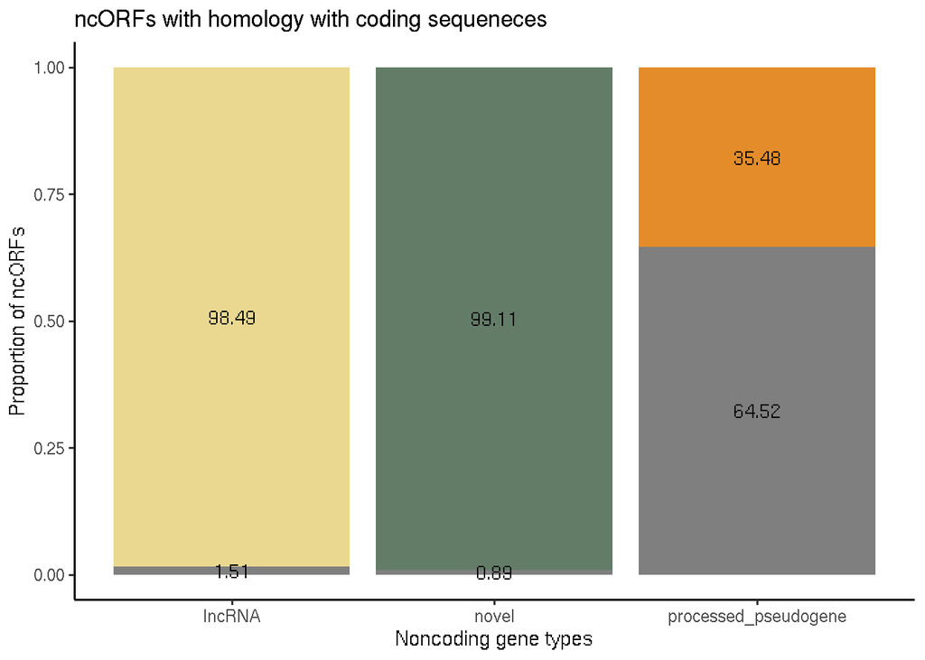

```
##
##               lncRNA_noncoding                novel_noncoding
##                            331                            224
## processed_pseudogene_noncoding       protein_coding_canonical
##                             31                            356
##            protein_coding_dORF           protein_coding_odORF
##                             31                             11
##           protein_coding_ouORF            protein_coding_uORF
##                             34                             65
```

```
##
##               lncRNA_noncoding                novel_noncoding
##                            326                            222
## processed_pseudogene_noncoding       protein_coding_canonical
##                             11                            356
##            protein_coding_dORF           protein_coding_odORF
##                             24                              6
##           protein_coding_ouORF            protein_coding_uORF
##                             34                             64
```

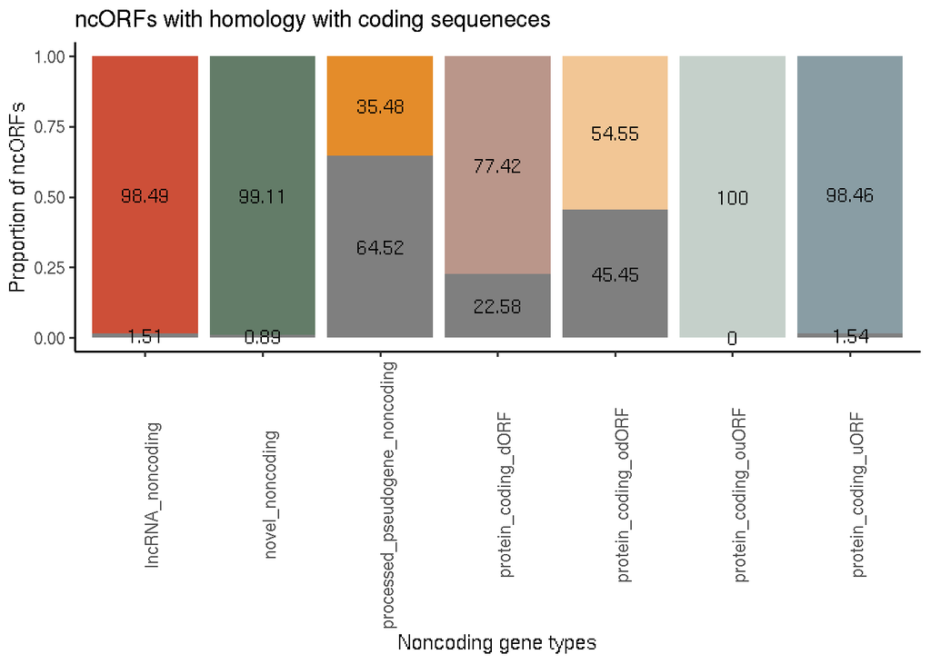

## TumorReactivated

- Expressed 3 times more in tumor than in normal in at least 5% of the patients of at least 1 cancer type of the studied ones.

`/home/marta/PROJECT_SCRIPTS/TestisRestricted_MP/TSTR_Pipeline/4_reconstructedTestis_log2ratio_altORFs.ipynb` `/home/marta/PROJECT_SCRIPTS/TestisRestricted_MPTSTR_Pipeline/5_Matrix_log2ratio_altORFs.Rmd` `/home/marta/PROJECT_SCRIPTS/TestisRestricted_MP/Q4.3_Heatmap_TTS_ctype.Rmd` - log2ratio

```
## [1] "ORFs"
```

```
##
##               lncRNA                novel processed_pseudogene
##                   35                   30                    1
##       protein_coding
##                  123
```

```
## [1] "altORFs"
```

```
##
##               lncRNA_noncoding                novel_noncoding
##                             35                             30
## processed_pseudogene_noncoding       protein_coding_canonical
##                              1                             90
##            protein_coding_dORF           protein_coding_odORF
##                              4                              1
##           protein_coding_ouORF            protein_coding_uORF
##                             10                             18
```

```
## [1] "Genes"
```

```
##
##               lncRNA                novel processed_pseudogene
##                   25                   22                    1
##       protein_coding
##                   92
```

```
##
##                        lncRNA_noncoding novel_noncoding
##   lncRNA                             25               0
##   novel                               0              22
##   processed_pseudogene                0               0
##   protein_coding                      0               0
##
##                        processed_pseudogene_noncoding protein_coding_canonical
##   lncRNA                                            0                        0
##   novel                                             0                        0
##   processed_pseudogene                              1                        0
##   protein_coding                                    0                       90
##
##                        protein_coding_dORF protein_coding_odORF
##   lncRNA                                 0                    0
##   novel                                  0                    0
##   processed_pseudogene                   0                    0
##   protein_coding                         4                    1
##
##                        protein_coding_ouORF protein_coding_uORF
##   lncRNA                                  0                   0
##   novel                                   0                   0
##   processed_pseudogene                    0                   0
##   protein_coding                         10                  14
```

```
## [1] "Per cancertype - genes"
```

```
##
##                  BLCA BRCA COAD KIRC LIHC LUAD LUSC PRAD
##   noncoding        16    5    2    7   17    6   22    5
##   protein_coding   37   17   14    4   48   13   44    5
```

```
##
## BLCA BRCA COAD KIRC LIHC LUAD LUSC PRAD
##   53   22   16   11   65   19   66   10
```

```
## [1] "Per cancertype - orfs"
```

```
##
##             BLCA BRCA COAD KIRC LIHC LUAD LUSC PRAD
##   altORFs     16    9    7    0   24    8   16    5
##   canonical   37   17   13    4   47   12   44    5
##   noncoding   23    5    2    9   19    7   35    7
```

```
##
## BLCA BRCA COAD KIRC LIHC LUAD LUSC PRAD
##   76   31   22   13   90   27   95   17
```

```
##     transcript_id         gene_id      gene_type gene_name        TPM
## 1 ENST00000381089 ENSG00000169059 protein_coding     VCX3A 0.00000000
## 2 ENST00000381059 ENSG00000182583 protein_coding       VCX 0.02603567
## 3 ENST00000543214 ENSG00000183304 protein_coding     FAM9A 0.00000000
## 4 ENST00000327968 ENSG00000184735 protein_coding     DDX53 0.00000000
## 5 ENST00000412172 ENSG00000224960 protein_coding   PPP4R3C 0.00000000
## 6 ENST00000451261 ENSG00000189186 protein_coding   DCAF8L2 0.00000000
##        patient   project normal_tumor ctype forced_TPM
## 1 TCGA-A7-A0CE TCGA-BRCA        tumor  BRCA          0
## 2 TCGA-A7-A0CE TCGA-BRCA        tumor  BRCA          0
## 3 TCGA-A7-A0CE TCGA-BRCA        tumor  BRCA          0
## 4 TCGA-A7-A0CE TCGA-BRCA        tumor  BRCA          0
## 5 TCGA-A7-A0CE TCGA-BRCA        tumor  BRCA          0
## 6 TCGA-A7-A0CE TCGA-BRCA        tumor  BRCA          0
```

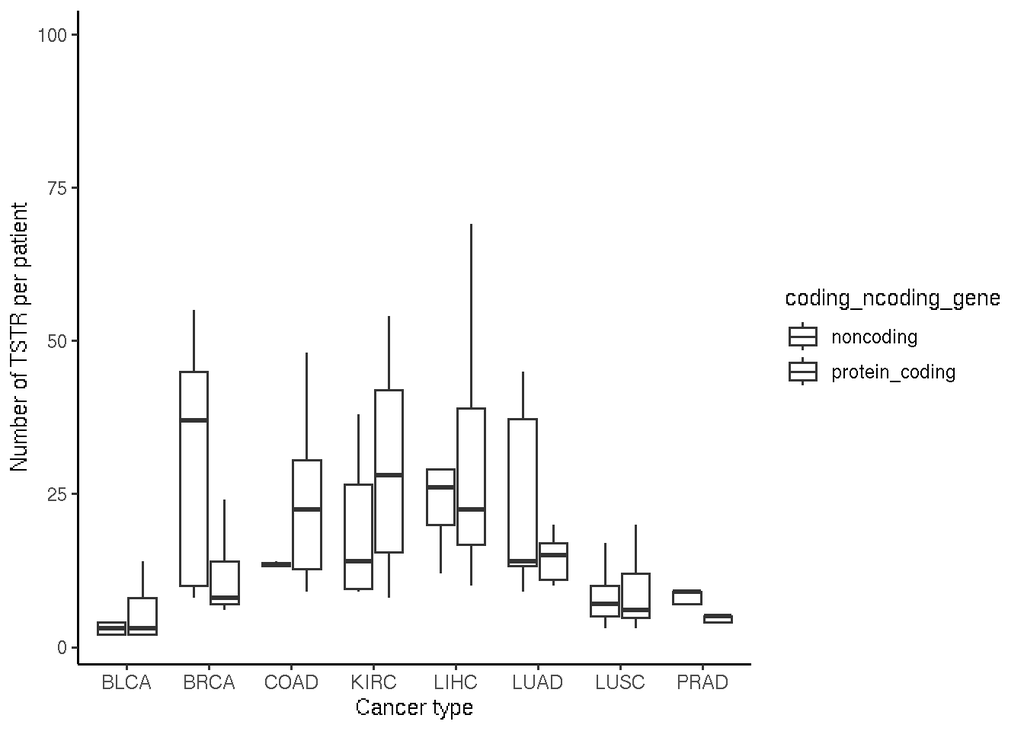

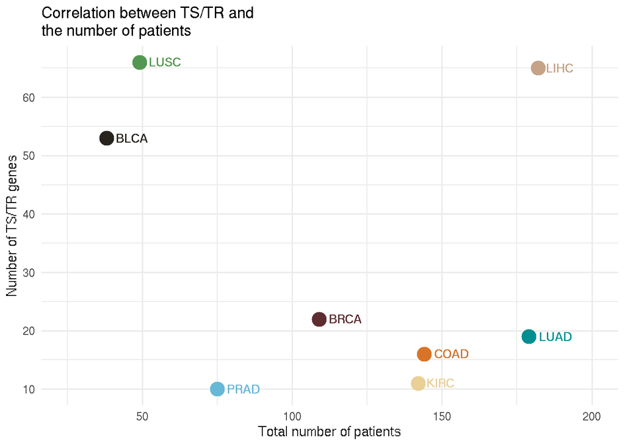

## Correlation testis expression vs tumor expression?

```
##     transcript_id         gene_id      gene_type gene_name      mean    median
## 1 ENST00000000412 ENSG00000003056 protein_coding      M6PR 36.248028 42.606992
## 2 ENST00000001008 ENSG00000004478 protein_coding     FKBP4 79.548884 73.831258
## 3 ENST00000001146 ENSG00000003137 protein_coding   CYP26B1 19.645508 19.378416
## 4 ENST00000002165 ENSG00000001036 protein_coding     FUCA2 13.580711 14.492918
## 5 ENST00000002596 ENSG00000002587 protein_coding    HS3ST1  1.978793  1.076031
## 6 ENST00000002829 ENSG00000001617 protein_coding    SEMA3F  3.664344  1.731854
##          sd    Q1.25%    Q3.75%
## 1 18.265719 29.129882 46.545656
## 2 14.242561 71.442426 84.796530
## 3 12.092824 13.533429 25.624041
## 4  8.199706  9.727982 17.889543
## 5  2.319074  0.661444  2.844761
## 6  4.424738  1.133210  5.229234
```

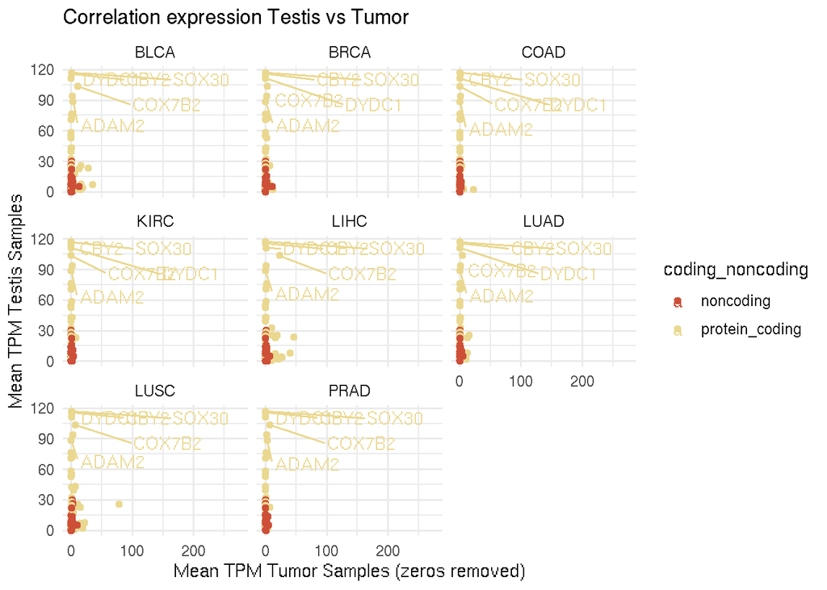

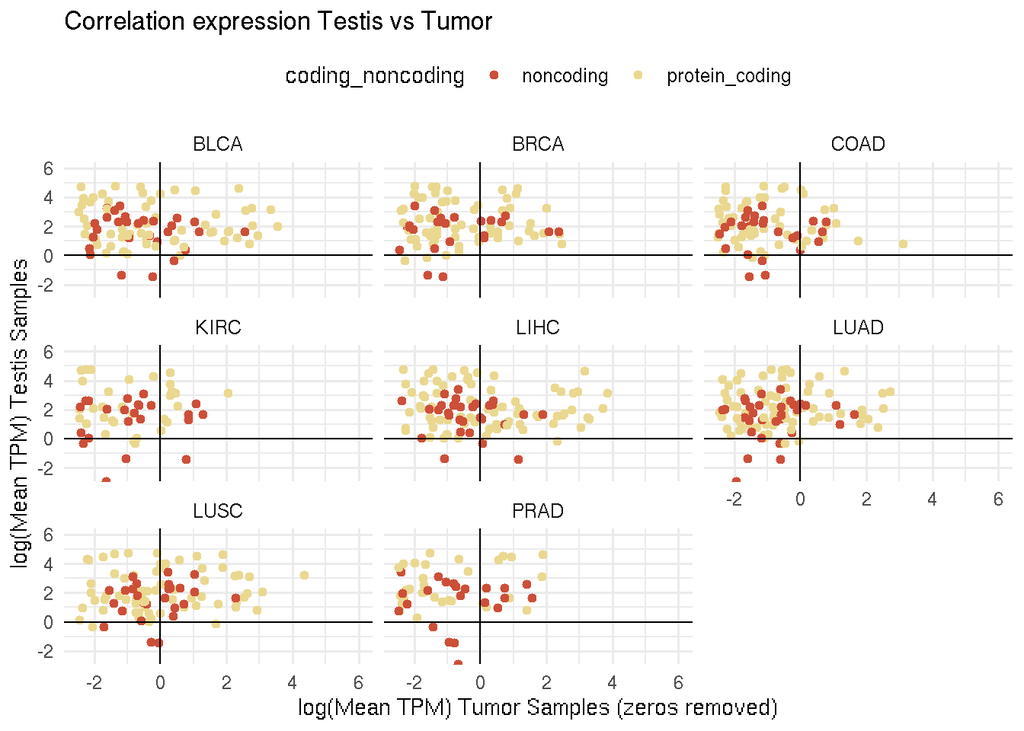

```
## [1] 58988
```

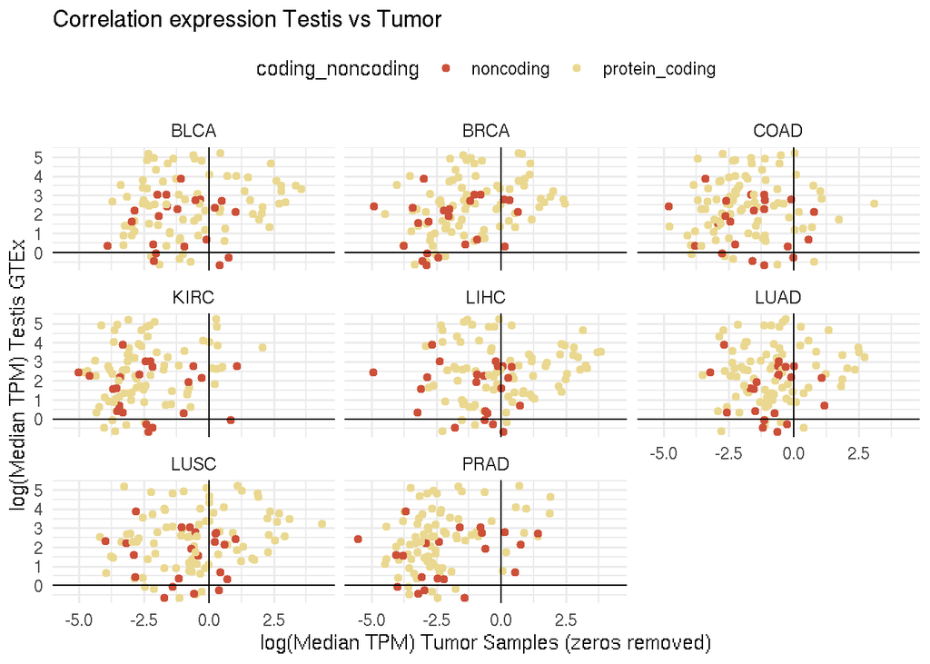

## Comparisons, from TestisSpecific, which are Reactivated and which are not

### Length

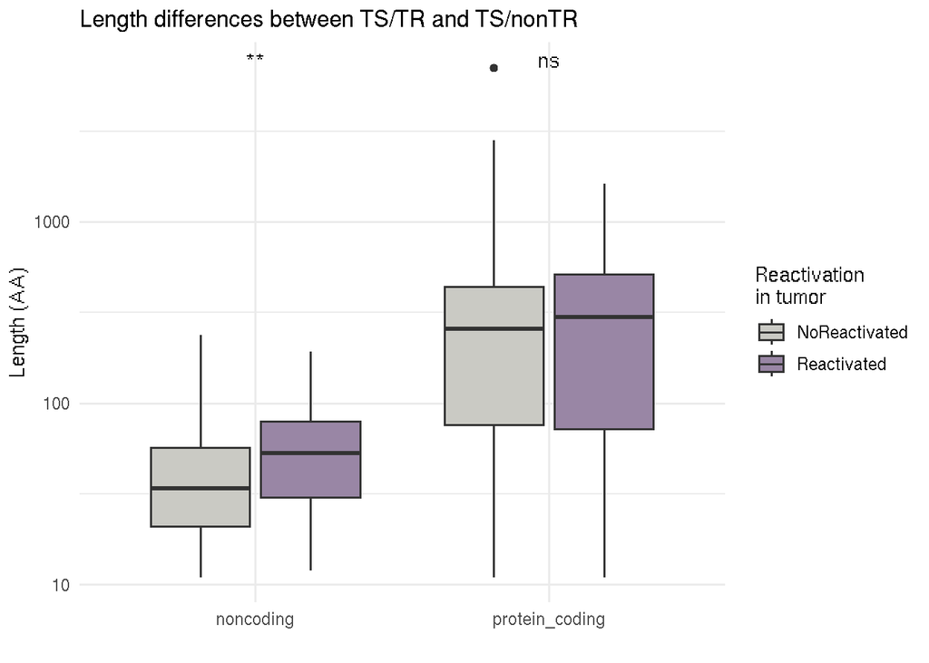

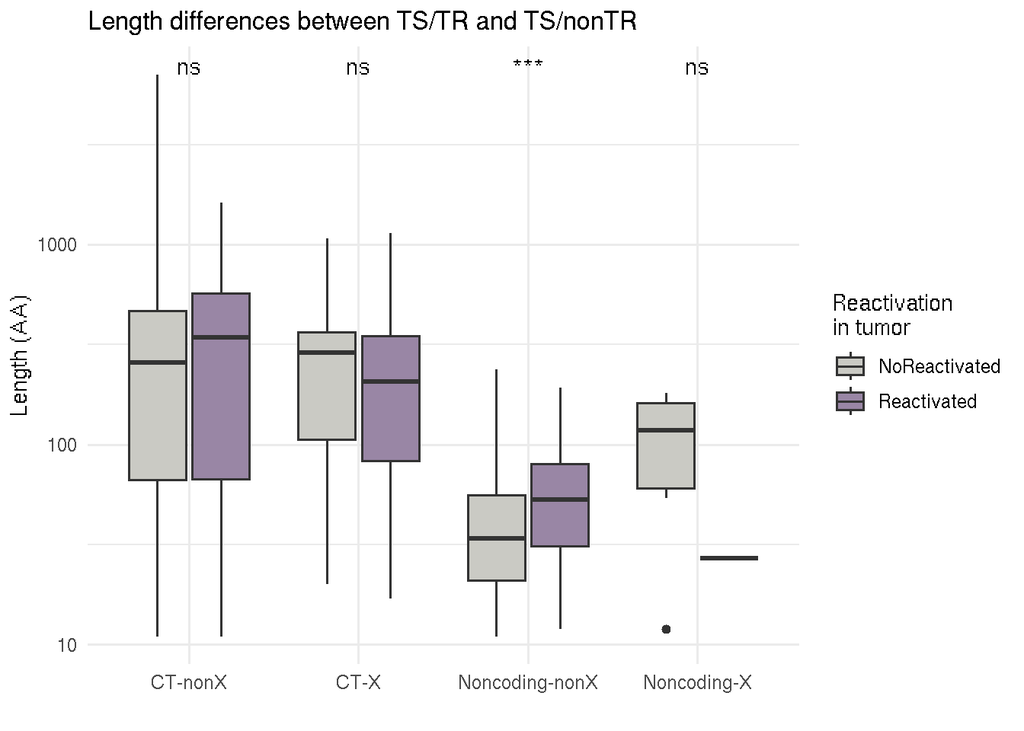

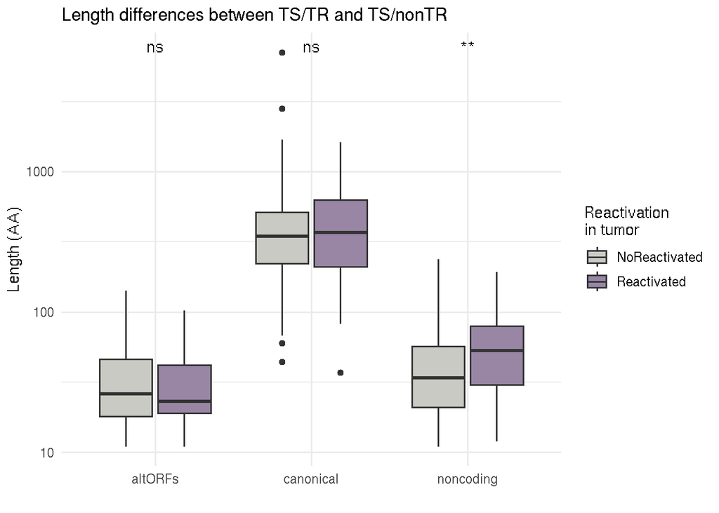

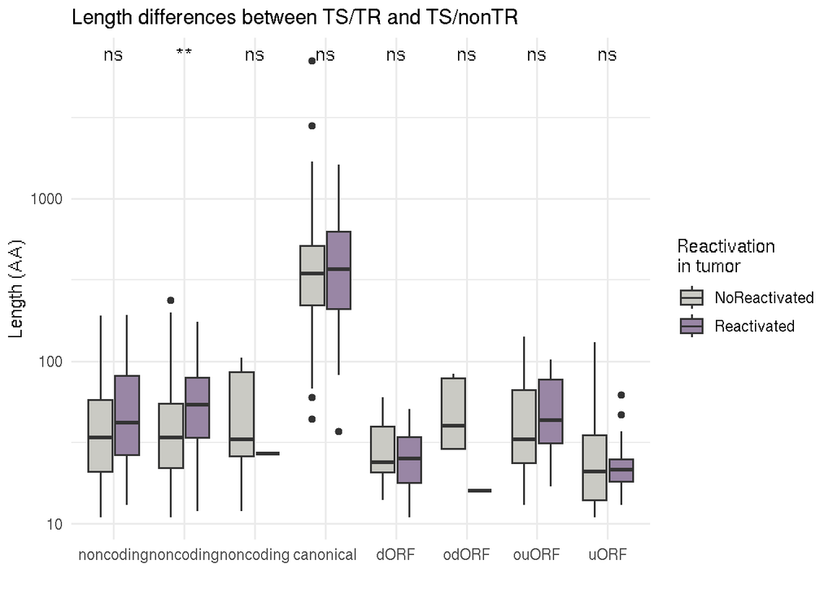

## Translation efficiency

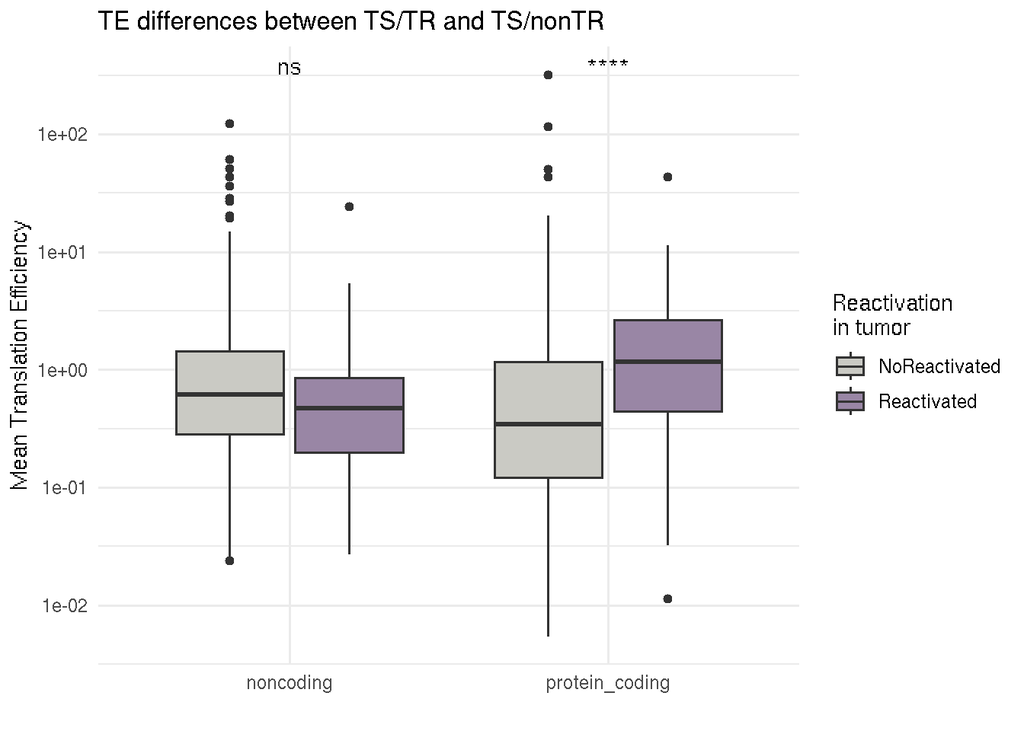

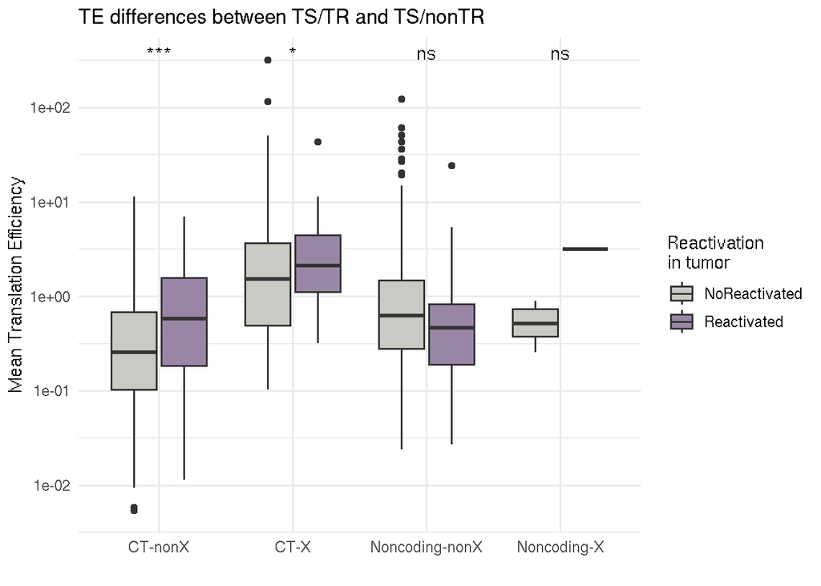

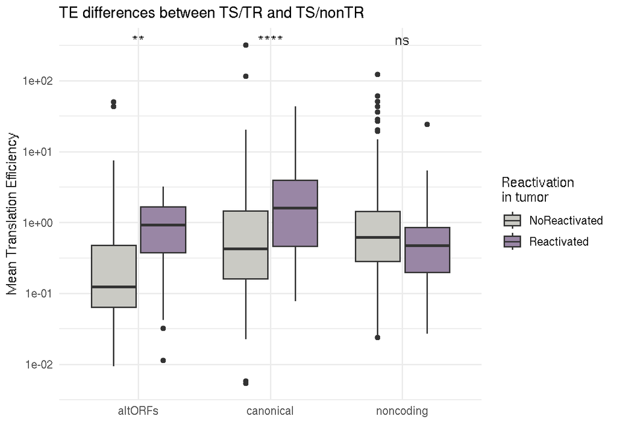

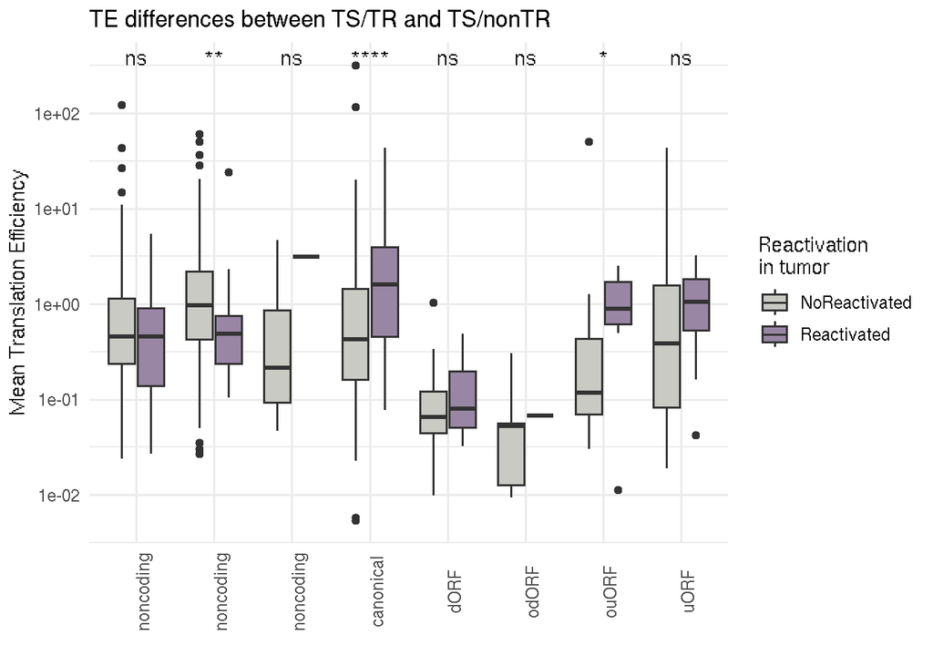

## Evolutionary conservation of ORFs

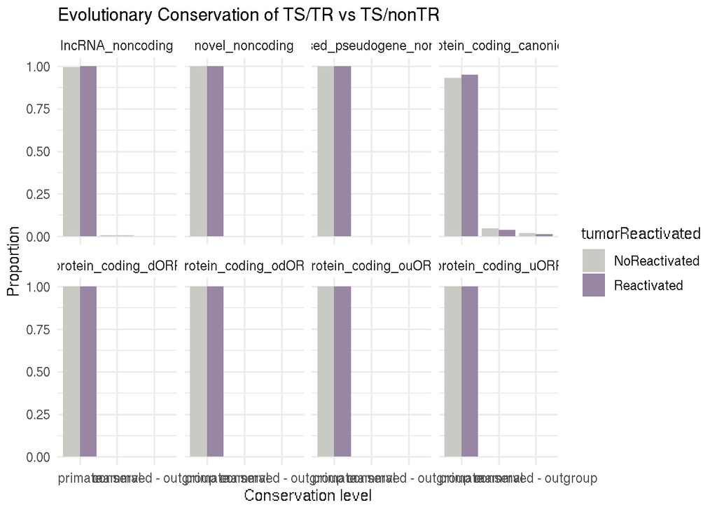

```
##
##  Fisher's Exact Test for Count Data
##
## data:  contingency_table
## p-value = 1
## alternative hypothesis: true odds ratio is not equal to 1
## 95 percent confidence interval:
##  0.3241029 7.2833007
## sample estimates:
## odds ratio
##   1.271495
```

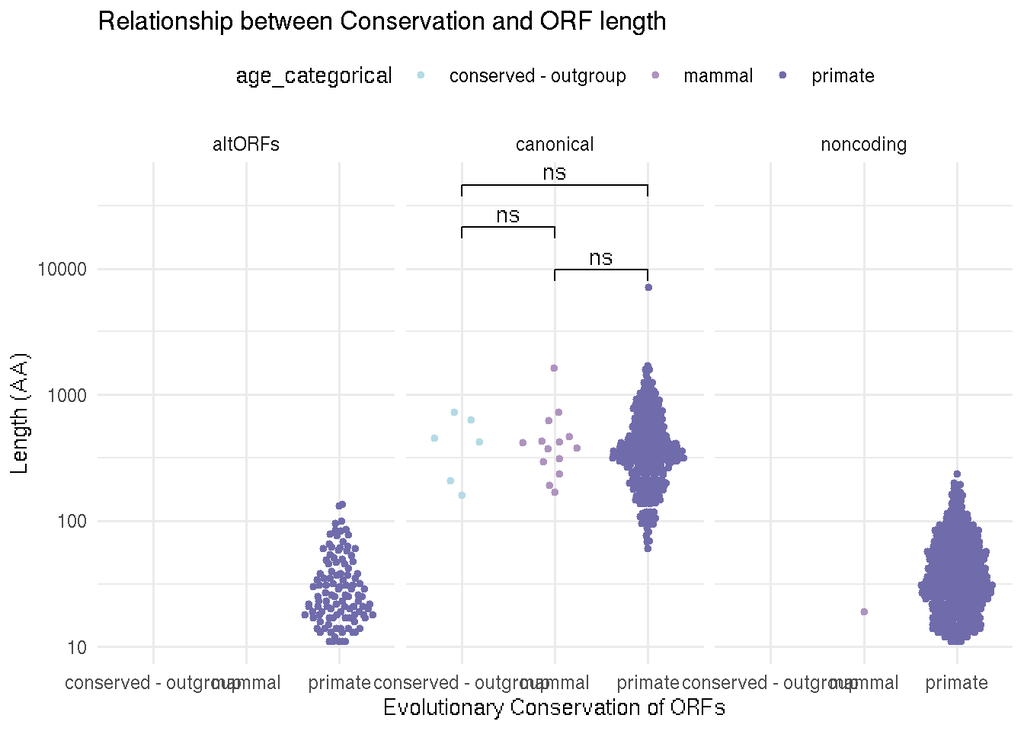

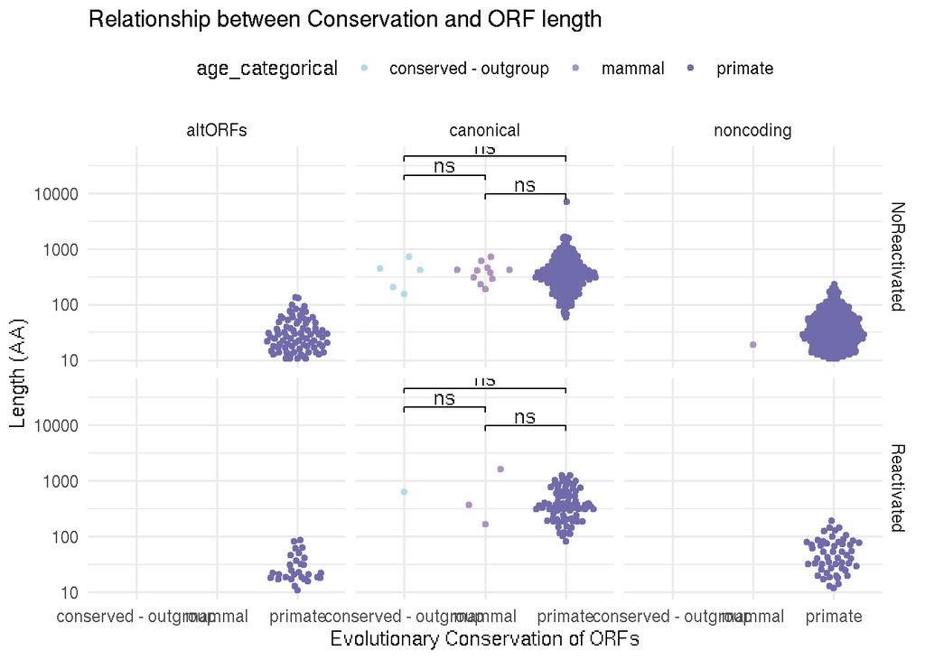

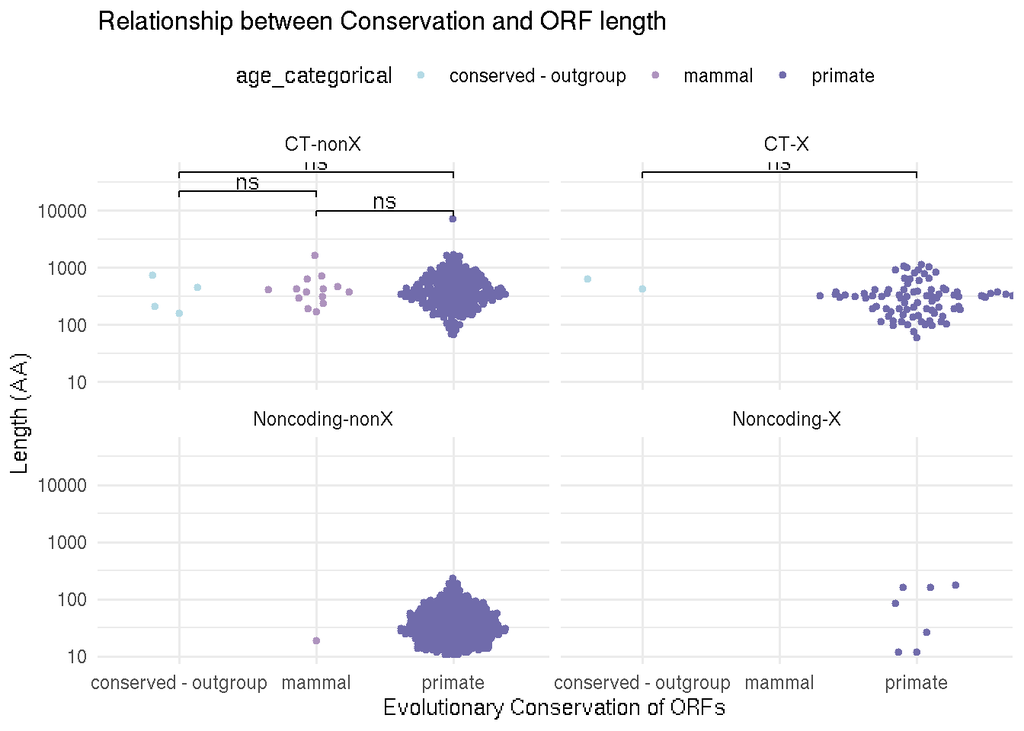

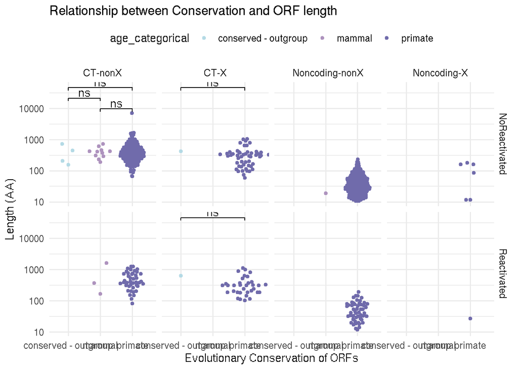

## Aminoacid Composition

First aa removed

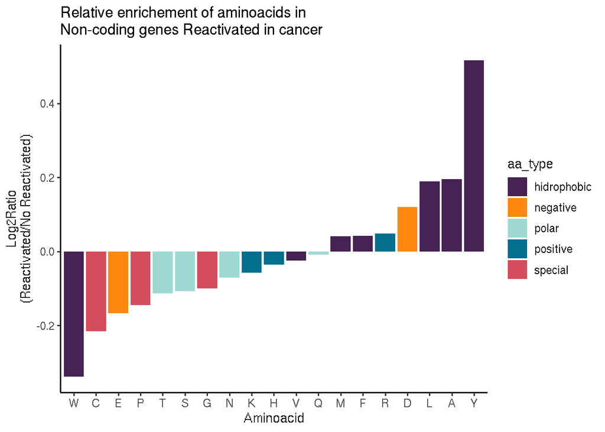

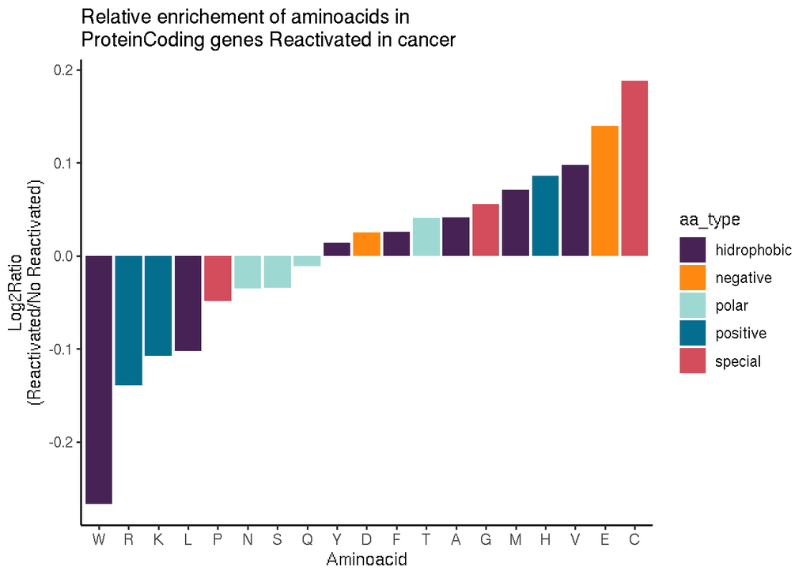

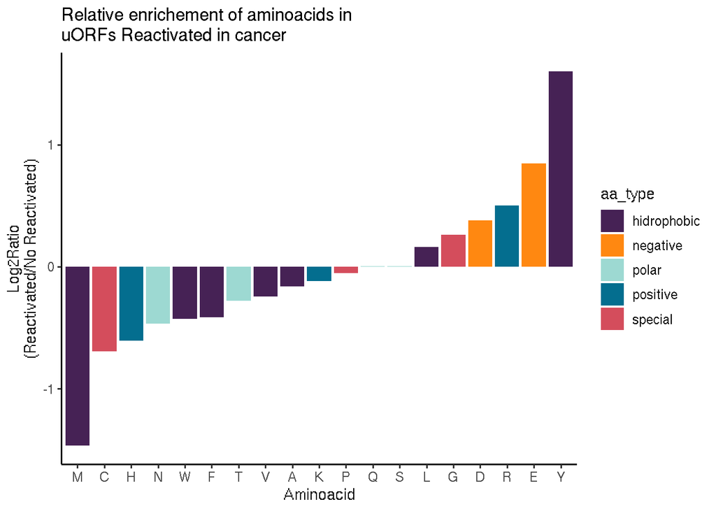